# HW3-Fogelman

## Kaelyn Fogelman

### Homework 3

### Due Date: 16 Oct 2020

Load packages necessary for the assignment.

```r
library(tidyverse)
library(lubridate)
```

## Covid Data

Load and check dataset

```r
covid <- read.csv("covid.csv", row.names = 1)
# Check data
str(covid)
```

```
## 'data.frame':    1106 obs. of  8 variables:
##  $ Date.of.birth               : Factor w/ 1076 levels "1/1/1930","1/1/1932",..: 62 698 126 141 299 978 642 539 25 572 ...
##  $ Hospitalization.type        : Factor w/ 3 levels "Home isolation",..: 1 2 1 1 3 3 3 1 1 3 ...
##  $ Symptoms                    : Factor w/ 2 levels "Asymptomatic",..: 2 2 2 2 2 2 2 2 2 2 ...
##  $ First.day.of.symptoms       : Factor w/ 112 levels "2/16/2020","2/19/2020",..: 6 7 7 8 6 32 10 7 40 40 ...
##  $ Outcome                     : Factor w/ 3 levels "Deceased","Disease in progress",..: 3 1 3 3 3 3 3 3 3 1 ...
##  $ Date.of.outcome             : Factor w/ 114 levels "3/13/2020","3/14/2020",..: 22 2 22 26 26 29 22 25 73 6 ...
##  $ Date.of.diagnosis           : Factor w/ 119 levels "3/10/2020","3/11/2020",..: 23 24 25 25 25 25 26 26 27 27 ...
##  $ Epidemiological.link...Notes: Factor w/ 201 levels "Asymptomatic",..: 106 152 201 198 8 200 200 136 136 136 ...
```

1. Correctly format the dates in “Date.of.birth”, “First.day.of.symptoms”, “Date.of.outcome” and “Date.of.diagnosis”.

```r
covid$Date.of.birth <-
  as.Date(parse_date_time(covid$Date.of.birth, "mdy"))

covid$First.day.of.symptoms <-
  as.Date(parse_date_time(covid$First.day.of.symptoms, "mdy"))

covid$Date.of.outcome <-
  as.Date(parse_date_time(covid$Date.of.outcome, "mdy"))

covid$Date.of.diagnosis <-
  as.Date(parse_date_time(covid$Date.of.diagnosis, "mdy"))
```

2. Format “Hospitalization.type”, “Symptoms” and “Outcome” as factors and “Epidemiological.link…Notes” as character.

```r
covid$Hospitalization.type <- as.factor(covid$Hospitalization.type)

covid$Symptoms <- as.factor(covid$Symptoms)

covid$Outcome <- as.factor(covid$Outcome)

covid$Epidemiological.link...Notes <- as.character(covid$Epidemiological.link...Notes)
```

3. Create a three-dimensional table reporting the three factors from the previous question. Hint: use the function table() with the variables of interest.

```r
table1 <- table(covid[c("Hospitalization.type", "Symptoms", "Outcome")])
table1
```

```
## , , Outcome = Deceased
##
##                                     Symptoms
## Hospitalization.type                 Asymptomatic Symptomatic
##   Home isolation                                2          15
##   Intensive care                                0          15
##   Non-Intensive care hospitalization            7         133
##
## , , Outcome = Disease in progress
##
##                                     Symptoms
## Hospitalization.type                 Asymptomatic Symptomatic
##   Home isolation                               64          20
##   Intensive care                                0           2
##   Non-Intensive care hospitalization            4          20
##
## , , Outcome = Healed
##
##                                     Symptoms
## Hospitalization.type                 Asymptomatic Symptomatic
##   Home isolation                              153         379
##   Intensive care                                1           9
##   Non-Intensive care hospitalization           17         261
```

4. Using a table object created in the previous question, subset it in order to create the following table:

```r
table2 <- table1[1:2, 2, c(2:3)]
table2
```

```
##                     Outcome
## Hospitalization.type Disease in progress Healed
##       Home isolation                  20    379
##       Intensive care                   2      9
```

```r
##Gabii's code
```

5. Order the data based on the date of diagnosis (from first to most recent).

```r
covid_diagnosis.date <- arrange(covid, Date.of.diagnosis)
head(covid_diagnosis.date)
```

```
##   Date.of.birth               Hospitalization.type    Symptoms
## 1    1956-01-22                     Home isolation Symptomatic
## 2    1943-05-03                     Intensive care Symptomatic
## 3    1996-10-16                     Home isolation Symptomatic
## 4    1989-10-21                     Home isolation Symptomatic
## 5    1964-12-14 Non-Intensive care hospitalization Symptomatic
## 6    1952-08-07 Non-Intensive care hospitalization Symptomatic
##   First.day.of.symptoms  Outcome Date.of.outcome Date.of.diagnosis
## 1            2020-02-25   Healed      2020-04-15        2020-03-05
## 2            2020-02-27 Deceased      2020-03-14        2020-03-06
## 3            2020-02-27   Healed      2020-04-15        2020-03-07
## 4            2020-02-28   Healed      2020-04-19        2020-03-07
## 5            2020-02-25   Healed      2020-04-19        2020-03-07
## 6            2020-03-03   Healed      2020-04-21        2020-03-07
##                                                                            Epidemiological.link...Notes
## 1                         In contact with a positive patient (outside province) in a club. Pediatrician
## 2                                                                     None of the common COVID symptoms
## 3                  Works in the Police. Has been close contact with positive patient (outside province)
## 4                                                   Travelled to Lombardia before being tested positive
## 5 Contact with covid positive patients during the course firefighters outside of province on 20.02.2020
## 6                                                                                               unknown
```

6. Add a column that reports whether or not a case was asymptomatic AND in home isolation. Name the observation “Home_Asymptomatic” if the conditions apply and “Non_Home_Asymptomatic” if not and then produce a bar plot of this new variable.

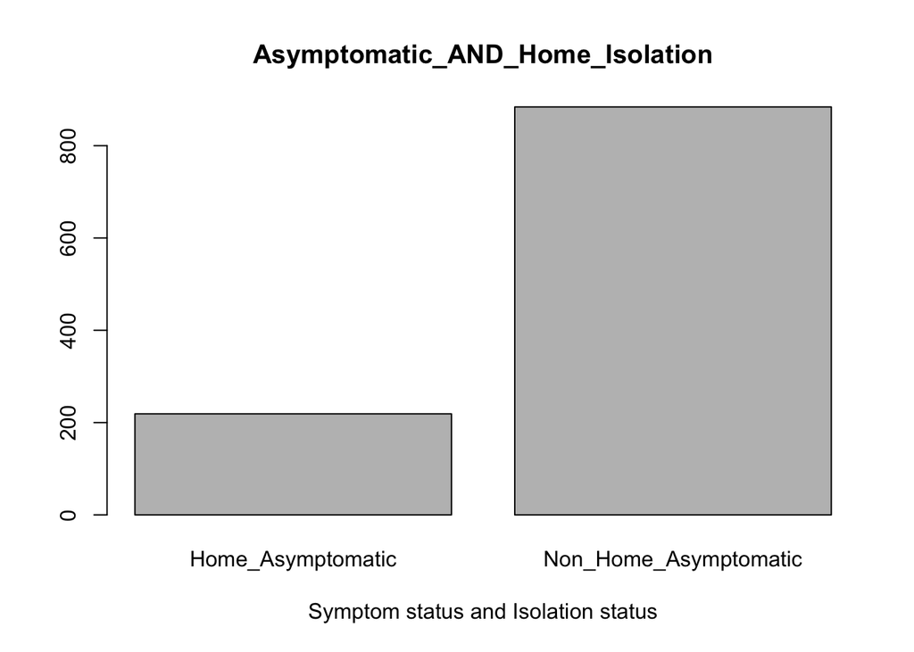

```r
covid <- covid %>%
  mutate(Asymptomatic_AND_Home_Isolation =
           ifelse(covid$Symptoms == "Asymptomatic" &
                  covid$Hospitalization.type == "Home isolation",
                  "Home_Asymptomatic", "Non_Home_Asymptomatic"))
counts <- table(covid$Asymptomatic_AND_Home_Isolation)
barplot(counts, main="Asymptomatic_AND_Home_Isolation",
   xlab="Symptom status and Isolation status")
```

7. Count the number of cases of people born after 1981 and that have healed.

```r
covid %>%
  filter(Date.of.birth > ymd(19810101) & Outcome == "Healed") %>%
  count()
```

```
##     n
## 1 158
```

**158 people that are were born after 1981 have healed.**

8. Count the number of cases that are asymptomatic OR in home isolation (but not both) AND were born before 1982.

```r
covid %>%
  filter(Symptoms == "Asymptomatic" | Hospitalization.type == "Home isolation"
         & Date.of.birth < ymd(19820101)) %>%
  count()
```

```
##     n
## 1 563
```

9. Create a new dataset including only the rows where “Epidemiological.link…Notes” includes the words “contact” OR “symptom” (or both). Hint: you can use the grep() function and tolower().

```r
covid_new_data <- covid %>% filter (grepl("contact", pattern =
                              tolower(covid$Epidemiological.link...Notes)) |
                              grepl("symptom", tolower(covid$Epidemiological.link...Notes)))
head(covid_new_data)
```

```
##   Date.of.birth               Hospitalization.type    Symptoms
## 1    1943-05-03                     Intensive care Symptomatic
## 2    1940-11-05 Non-Intensive care hospitalization Symptomatic
## 3    1935-11-17 Non-Intensive care hospitalization Symptomatic
## 4    1953-02-13 Non-Intensive care hospitalization Symptomatic
## 5    1953-08-24                     Home isolation Symptomatic
## 6    1997-08-25                     Home isolation Symptomatic
##   First.day.of.symptoms  Outcome Date.of.outcome Date.of.diagnosis
## 1            2020-02-27 Deceased      2020-03-14        2020-03-06
## 2            2020-03-05   Healed      2020-04-22        2020-03-12
## 3            2020-03-02   Healed      2020-05-13        2020-03-13
## 4            2020-03-04   Healed      2020-04-28        2020-03-14
## 5            2020-03-14   Healed      2020-04-21        2020-03-15
## 6            2020-03-11   Healed      2020-04-18        2020-03-16
##        Epidemiological.link...Notes Asymptomatic_AND_Home_Isolation
## 1 None of the common COVID symptoms           Non_Home_Asymptomatic
## 2                      Flu symptoms           Non_Home_Asymptomatic
## 3                      Flu symptoms           Non_Home_Asymptomatic
## 4                      Flu symptoms           Non_Home_Asymptomatic
## 5                      Flu symptoms           Non_Home_Asymptomatic
## 6                      Flu symptoms           Non_Home_Asymptomatic
```

10. In the previous dataset add a column reporting the age (in years, therefore in integer format) of each patient as of October 2nd, 2020. Save this dataset into a .csv file and make it available on your GitHub repository for this assignment.

```r
covid_new_data <- covid_new_data %>%
  mutate("Age" = as.period(interval(covid_new_data$Date.of.birth,
      ymd("2020 October 2")))$year) %>%
           write_csv("hw3.kf.new_data_set.csv")
```

11. Produce a pie chart for the type of hospitalization for cases born between 1960 and 1980.

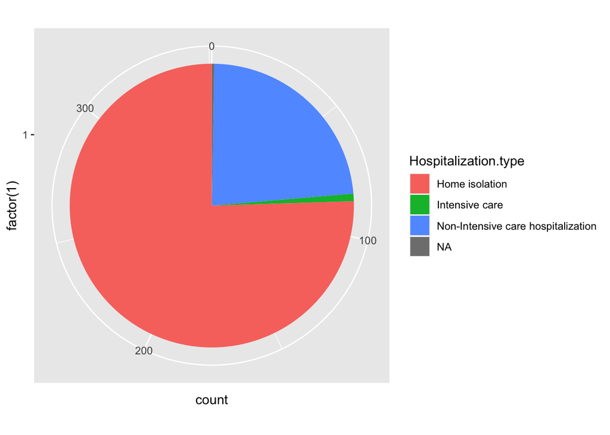

```r
library(ggplot2)
pie_covid_df <- subset(covid, covid$Date.of.birth >= as.Date("1960-01-01") &
         covid$Date.of.birth <= as.Date("1980-01-01"))

ggplot(pie_covid_df, aes(x=factor(1), fill=Hospitalization.type))+
    geom_bar(width = 1)+
    coord_polar("y")
```

## Salary

1. Load the data and check the formatting of the variables.

```r
adult <- read.csv("adult.csv", row.names = 1)
# Check data
str(adult)
```

```
## 'data.frame':    32561 obs. of  15 variables:
##  $ age           : int  39 50 38 53 28 37 49 52 31 42 ...
##  $ workclass     : Factor w/ 9 levels " ?"," Federal-gov",..: 8 7 5 5 5 5 5 7 5 5 ...
##  $ fnlwgt        : int  77516 83311 215646 234721 338409 284582 160187 209642 45781 159449 ...
##  $ education     : Factor w/ 16 levels " 10th"," 11th",..: 10 10 12 2 10 13 7 12 13 10 ...
##  $ education.num : int  13 13 9 7 13 14 5 9 14 13 ...
##  $ marital.status: Factor w/ 7 levels " Divorced"," Married-AF-spouse",..: 5 3 1 3 3 3 4 3 5 3 ...
##  $ occupation    : Factor w/ 15 levels " ?"," Adm-clerical",..: 2 5 7 7 11 5 9 5 11 5 ...
##  $ relationship  : Factor w/ 6 levels " Husband"," Not-in-family",..: 2 1 2 1 6 6 2 1 2 1 ...
##  $ race          : Factor w/ 5 levels " Amer-Indian-Eskimo",..: 5 5 5 3 3 5 3 5 5 5 ...
##  $ sex           : Factor w/ 2 levels " Female"," Male": 2 2 2 2 1 1 1 2 1 2 ...
##  $ capital.gain  : int  2174 0 0 0 0 0 0 0 14084 5178 ...
##  $ capital.loss  : int  0 0 0 0 0 0 0 0 0 0 ...
##  $ hours.per.week: int  40 13 40 40 40 40 16 45 50 40 ...
##  $ native.country: Factor w/ 42 levels " ?"," Cambodia",..: 40 40 40 40 6 40 24 40 40 40 ...
##  $ NA.           : Factor w/ 2 levels " <=50K"," >50K": 1 1 1 1 1 1 1 2 2 2 ...
```

2. Rename the last column (currently called “NA”) containing the dichotomous salary information. Assign the name salary to it.

```r
adult <- rename(adult, salary = 15)
head(adult)
```

```
##   age         workclass fnlwgt  education education.num      marital.status
## 1  39         State-gov  77516  Bachelors            13       Never-married
## 2  50  Self-emp-not-inc  83311  Bachelors            13  Married-civ-spouse
## 3  38           Private 215646    HS-grad             9            Divorced
## 4  53           Private 234721       11th             7  Married-civ-spouse
## 5  28           Private 338409  Bachelors            13  Married-civ-spouse
## 6  37           Private 284582    Masters            14  Married-civ-spouse
##           occupation   relationship   race     sex capital.gain capital.loss
## 1       Adm-clerical  Not-in-family  White    Male         2174            0
## 2    Exec-managerial        Husband  White    Male            0            0
## 3  Handlers-cleaners  Not-in-family  White    Male            0            0
## 4  Handlers-cleaners        Husband  Black    Male            0            0
## 5     Prof-specialty           Wife  Black  Female            0            0
## 6    Exec-managerial           Wife  White  Female            0            0
##   hours.per.week native.country salary
## 1             40  United-States  <=50K
## 2             13  United-States  <=50K
## 3             40  United-States  <=50K
## 4             40  United-States  <=50K
## 5             40           Cuba  <=50K
## 6             40  United-States  <=50K
```

3. The values in salary have a space in front of them (e.g. " >50K"): remove the space from all values (hint: you can use substring()).

```r
adult$salary <- trimws(adult$salary, which = c("left"))
```

4. Again, in the variable salary, replace “>50K” with the value 1 and “<=50K” with 0. Make sure to format it as a factor with two levels.

```r
adult2 <- adult %>%
  mutate(salary = recode(salary, ">50K" = "1",
                                   "<=50K" = "0"))
adult2$salary <- as.numeric(adult2$salary)
```

5. Use the glm() function to estimate this logistic model. Only specify the arguments formula = salary ~ ., data and family = binomial. Save the result of the estimation in an object called fit.

```r
fit = glm(formula = salary ~ ., data = adult2, family = binomial)
```

6. Using the information in fit (hint: you can use the functions coef() and summary() to extract information), create a dataframe collecting:  
6.1 The names of the variables (names of the rows of the dataframe);  
6.2 The value of the coefficients (first column);  
6.3 A logical vector stating which coefficients are positive (second column);  
6.4 The p-values (third column).

```r
##Variable names, column 1
df <- data.frame (row.names1 = (as.data.frame(coef(fit))%>%
              drop_na() %>%
              row.names() ))

##Coefficient value, column 2
df$coef.value <- drop_na (as.data.frame(coef(fit)))[[1]]

##Positive coefficient = TRUE, negative coefficient = FALSE, column 3
df <- df %>%
  mutate("positive.coef" = as.logical(coef.value > 0))

##p-value, column 4
df$p.value <- as.data.frame(summary(fit)[["coefficients"]])$'Pr(>|z|)'

head(df)
```

```
##               row.names1   coef.value positive.coef      p.value
## 1            (Intercept)  -9.07389101         FALSE 2.686478e-94
## 2                    age   0.02551755          TRUE 6.481160e-54
## 3  workclass Federal-gov   1.09674300          TRUE 9.993926e-13
## 4    workclass Local-gov   0.41176469          TRUE 3.344208e-03
## 5 workclass Never-worked -10.45447339         FALSE 9.693605e-01
## 6      workclass Private   0.59437410          TRUE 2.075863e-06
```

7. Subset the dataframe created in the previous question to only show the rows where the p-values are strictly smaller than 0.05. Knowing that (i) the remaining rows are statistically significant and that (ii) positive coefficients contribute to increase the probability of a salary larger than $50,000 (the opposite for negative values), comment on those variables that negatively contribute to salary.

```r
sigvar <- df %>%
  filter (df$p.value < 0.05)
sigvar
```

```
##                           row.names1    coef.value positive.coef       p.value
## 1                        (Intercept) -9.073891e+00         FALSE  2.686478e-94
## 2                                age  2.551755e-02          TRUE  6.481160e-54
## 3              workclass Federal-gov  1.096743e+00          TRUE  9.993926e-13
## 4                workclass Local-gov  4.117647e-01          TRUE  3.344208e-03
## 5                  workclass Private  5.943741e-01          TRUE  2.075863e-06
## 6             workclass Self-emp-inc  7.694380e-01          TRUE  2.743718e-07
## 7                             fnlwgt  7.071699e-07          TRUE  3.932934e-05
## 8                  education 7th-8th -4.755371e-01         FALSE  4.039320e-02
## 9               education Assoc-acdm  1.335553e+00          TRUE  3.627672e-14
## 10               education Assoc-voc  1.352104e+00          TRUE  1.454137e-15
## 11               education Bachelors  1.936183e+00          TRUE  9.495413e-35
## 12               education Doctorate  2.989458e+00          TRUE  2.970710e-44
## 13                 education HS-grad  8.134141e-01          TRUE  1.145786e-07
## 14                 education Masters  2.288893e+00          TRUE  2.616565e-42
```

[output cut: 31 more lines]

**Variables that contribute negatively to salary include: education 7th-8th , marital.status Never-married, occupation Farming-fishing, occupation Handlers-cleaners, occupation Other-service, occupation Priv-house-serv, relationship Own-child, native.country Columbia, native.country South.**

**Based on this analysis, education impacts salary with indivudals having a lower education level (7th-8th grade) having their salary negatively impacted compared to individuals that have higher education levels.**

**Individuals that have never been married have their salary negatively impacted compared to individuals who are currently married or have been married previously and are separated or widowed.**

**Individuals who have occupations that are labor, service or domestic based have their salaries more negatively impacted to individuals who have more technical or professional occupations.**

**Considering family relationships, having children in the household impacts salary more significantly than other family relationships including marriage or having a non-child relative in the household.**

**Those from the countries of Columbia and "South" (could indicate South Korea or South Africa - not indicated in the data set) have their salaries more negatively influenced than individuals with other countries of origin.**

## Bonus

```r
library(leaflet)
library(htmltools)
```

```r
teams <- c("Real Madrid", "FC Barcelona", "Atletico Madrid",
           "Atletico Bilbao", "Valencia")
champions <- c(34, 26, 10, 8, 6)
city <- c("Madrid", "Barcelona", "Madrid", "Bilbao", "Valencia")

map.df <- cbind(teams, champions, city)

head(map.df)
```

```
##      teams             champions city
## [1,] "Real Madrid"     "34"      "Madrid"
## [2,] "FC Barcelona"    "26"      "Barcelona"
## [3,] "Atletico Madrid" "10"      "Madrid"
## [4,] "Atletico Bilbao" "8"       "Bilbao"
## [5,] "Valencia"        "6"       "Valencia"
```

Create base map

```r
map <- leaflet() %>%
  setView(lng = 0.8891, lat = 41.6488, zoom = 4) %>%
  addTiles()
map
```

[interactive chart not shown]

```r
content <- paste(sep = "<br/>",
                 "<b>Real Madrid</b>",
                 "34",
                 "<b>Atletico Madrid</b>",
                 "10")

content2 <- paste(sep = "<br/>",
                 "<b>FC Barcelona</b>",
                 "26")

content3 <- paste(sep = "<br/>",
                 "<b>Athletic Bilbao</b>",
                 "8")

content4 <- paste(sep = "<br/>",
                 "<b>Valencia</b>",
                 "6")

map <- map %>%
  leaflet() %>%
  addTiles() %>%
  addPopups (-3.7038, 40.4168, content,
             options = popupOptions(closeButton = FALSE)) %>%
  addPopups (-2.1734, 41.3851, content2,
             options = popupOptions(closeButton = FALSE)) %>%
  addPopups (-2.9350, 43.2630, content3,
             options = popupOptions(closeButton = FALSE)) %>%
  addPopups (-0.3763, 39.4699, content4,
             options = popupOptions(closeButton = FALSE)) %>%
  addCircles (lng = -3.7038, lat = 40.4168, weight = 5,
              radius = (34000 * 2)) %>%
  addCircles (lng = -3.7038, lat = 40.4168, weight = 5,
              radius = (10000 * 2)) %>%
  addCircles (lng = -2.1734, lat = 41.3851, weight = 5,
              radius = (26000 * 2)) %>%
  addCircles (lng = -2.9350, lat = 43.2630, weight = 5,
              radius = (8000 * 2)) %>%
  addCircles (lng = -0.3763, lat = 39.4699, weight = 5,
              radius = (6000 * 2))

map
```

[interactive chart not shown]